# lab5

Hugo Morvan, Daniele Bozzoli

2023-12-05

# Question 1: Hypothesis testing

In 1970, the US Congress instituted a random selection process for the military draft. All 366 possible birth dates were placed in plastic capsules in a rotating drum and were selected one by one. The first date drawn from the drum received draft number one, the second date drawn received draft number two, etc. Then, eligible men were drafted in the order given by the draft number of their birth date. In a truly random lottery there should be no relationship between the date and the draft number. Your task is to investigate whether there can be doubts concerning the randomness of the selection of the draft numbers. The draft numbers (Y=Draft_No) sorted by day of year (X=Day_of_year) are given in the file lottery.csv. The data was originally published by the U.S. Government, and most conveniently made available online at http://jse.amstat.org/jse_data_archive.htm (see also Starr Norton (1997) Nonrandom Risk: The 1970 Draft Lottery, Journal of Statistics Education, 5:2, DOI: 10.1080/10691898.1997.11910534)

## 1.

Create a scatterplot of Y versus X, are any patterns visible?

```
##       Day           Month             Mo.Number       Day_of_year
##  Min.   : 1.00   Length:366         Min.   : 1.000   Min.   :  1.00
##  1st Qu.: 8.00   Class :character   1st Qu.: 4.000   1st Qu.: 92.25
##  Median :16.00   Mode  :character   Median : 7.000   Median :183.50
##  Mean   :15.76                      Mean   : 6.514   Mean   :183.50
##  3rd Qu.:23.00                      3rd Qu.: 9.750   3rd Qu.:274.75
##  Max.   :31.00                      Max.   :12.000   Max.   :366.00
##     Draft_No
##  Min.   :  1.00
##  1st Qu.: 92.25
##  Median :183.50
##  Mean   :183.53
##  3rd Qu.:274.75
##  Max.   :366.00
```

```
##
## Call:
## lm(formula = Draft_No ~ Day_of_year, data = data)
##
## Residuals:
##      Min       1Q   Median       3Q      Max
## -210.837  -85.629   -0.519   84.612  196.157
##
## Coefficients:
##              Estimate Std. Error t value Pr(>|t|)
## (Intercept) 225.00922   10.81197  20.811  < 2e-16 ***
## Day_of_year  -0.22606    0.05106  -4.427 1.26e-05 ***
## ---
## Signif. codes:  0 '***' 0.001 '**' 0.01 '*' 0.05 '.' 0.1 ' ' 1
##
## Residual standard error: 103.2 on 364 degrees of freedom
## Multiple R-squared:  0.05109,    Adjusted R-squared:  0.04849
## F-statistic:  19.6 on 1 and 364 DF,  p-value: 1.264e-05
```

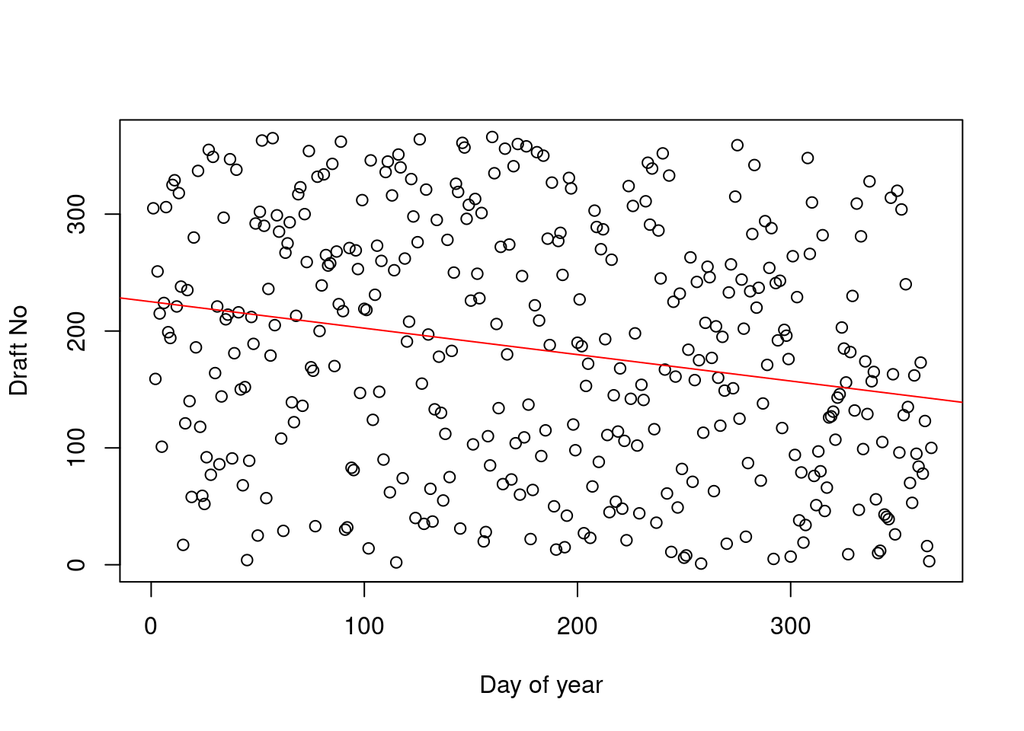

```
## Call:
## loess(formula = Draft_No ~ Day_of_year, data = data)
##
## Number of Observations: 366
## Equivalent Number of Parameters: 4.35
## Residual Standard Error: 103
## Trace of smoother matrix: 4.73  (exact)
##
## Control settings:
##   span     :  0.75
##   degree   :  2
##   family   :  gaussian
##   surface  :  interpolate      cell = 0.2
##   normalize:  TRUE
##  parametric:  FALSE
## drop.square:  FALSE
```

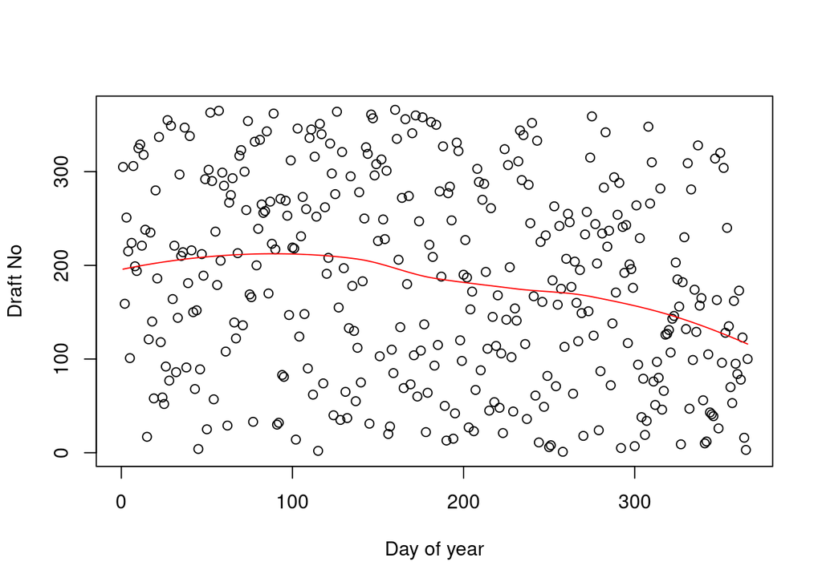

## 3.

In order to check if the lottery is random, one can use various statistics. One such possibility is based on the expected responses. The fitted loess smoother provides an estimate $\hat{Y}$ as a function of X. It the lottery was random, we would expect $\hat{Y}$ to be a flat line, equaling the empirical mean of the observed responses, Y . The statistic we will consider will be
$$S =
\sum_{i=1}^{n}|\hat{Y}_i-\bar{Y}|$$

If S is not close to zero, then this indicates some trend in the data, and throws suspicion on the randomness of the lottery. Estimate S’s distribution through a non–parametric bootstrap, taking B = 2000 bootstrap samples. Decide if the lottery looks random, what is the p–value of the observed value of S.

```
## [1] 8238.649
```

```
## [1] 0.565
```

## 4.

We will now want to investigate the power of our considered test. First based on the test statistic S, implement a function that tests the hypothesis H0 : Lottery is random versus H1 : Lottery is non–random. The function should return the value of S and its p–value, based on 2000 bootstrap samples.

```
## $S
## [1] 8238.649
##
## $p_value
## [1] 0
```

## 5.

Now we will try to make a rough estimate of the power of the test constructed in Step 4 by generating more and more biased samples:

1. Create a dataset of the same dimensions as the original data. Choose k, out of the 366, dates and assign them the end numbers of the lottery (i.e., they are not legible for the draw). The remaining 366 - k dates should have random numbers assigned (from the set {1,…, 366 - k}). The k dates should be chosen in two ways:
1. k consecutive dates,
2. as blocks (randomly scattered) of $\lfloor k/3 \rfloor$ consecutive dates (this is of course for $k ≥ 3$, and if k is not divisible by 3, then some blocks can be of length $\lfloor k/3 \rfloor +1$).

*** We got stuck on this question. We are hopping to get some feedback and/or cues during the seminar. ***

2. For each of the Plug the two new not–completely–random datasets from item 5a into the bootstrap test with B = 2000 and note whether it was rejected.

```
## [1] 0.5485
```

3. Repeat Steps 5a–5b for k = 1, … , until you have observed a couple of rejections.

How good is your test statistic at rejecting the null hypothesis of a random lottery?

# Question 2: Bootstrap, jackknife and coincidence intervals

The data you are going to continue analyzing is the database of home prices in Albuquerque, 1993. The variables present are Price; SqFt: the area of a house; FEATS: number of features such as dishwasher, refrigerator and so on; Taxes: annual taxes paid for the house. Explore the file prices1.xls. The source of the original is the Data and Story Library (https://dasl.datadescription.com/) and it can be recovered from (https://web.archive.org/web/20151022095618/http://lib.stat.cmu.edu/DASL/Datafiles/homedat.html).

## 1.

Create a scatter plot of SqFt versus Price. Fit a linear model to it. Does a straight line seem like a good fit?

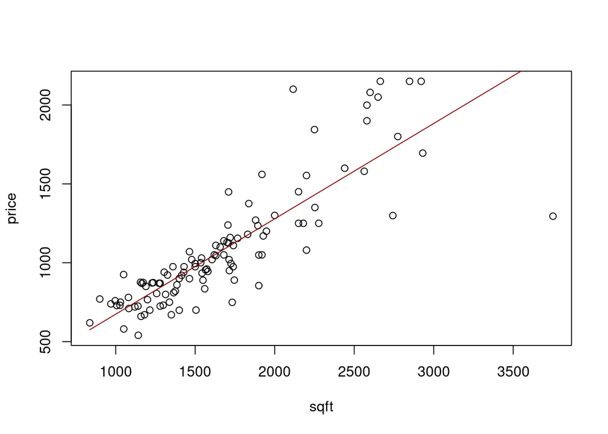

A straight line seems to summarize the data pretty well.

## 2.

While the data do seem to follow a linear trend, a new sort of pattern seems to appear around 2000ft2. Consider a new linear model

$Price = b + a_1 * SqFt + a_2 * (SqFt - c) * 1_{SqFt>c}$ where c is the area value where the model changes. You can determine c using an optimizer, e.g., optim(), with the residual sum of squares (RSS) as the value to be minimized. For each value of c, the objective function should estimate b, a1, and a2; then calculate (and return) the resulting RSS.

```
## [1] 3033.528
```

```
## [1] 3309413
```

## 3.

Using the bootstrap estimate the distribution of c. Determine the bootstrap bias{correction and the variance of c. Compute a 95% confidence interval for c using bootstrap percentile, bootstrap BCa, and first{order normal approximation

(Hint: use boot(),boot.ci(),plot.boot(),print.bootci())

```
## 500
1000
1500
2000
```

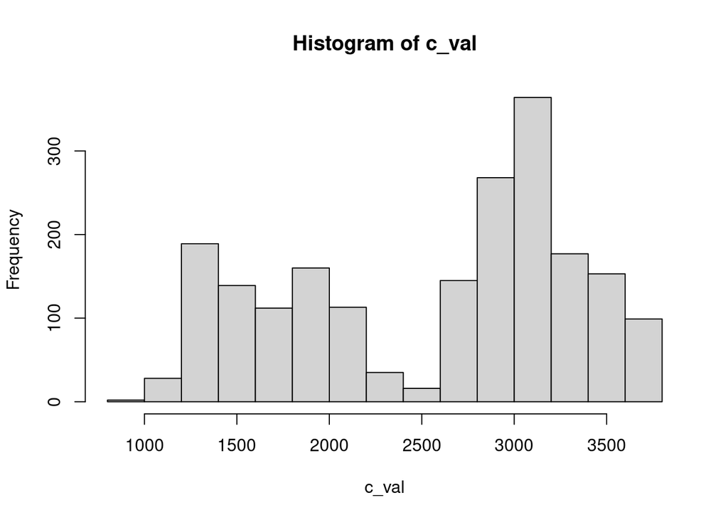

```
## [1] 3501.055
```

```
## [1] 580635.3
```

```
## BOOTSTRAP CONFIDENCE INTERVAL CALCULATIONS
## Based on 2000 bootstrap replicates
##
## CALL :
## boot.ci(boot.out = boot_fun)
##
## Intervals :
## Level      Normal              Basic
## 95%   (2549, 5481 )   (2943, 5286 )
##
## Level     Percentile            BCa
## 95%   (1299, 3642 )   (2848, 3748 )
## Calculations and Intervals on Original Scale
## Warning : BCa Intervals used Extreme Quantiles
## Some BCa intervals may be unstable
```

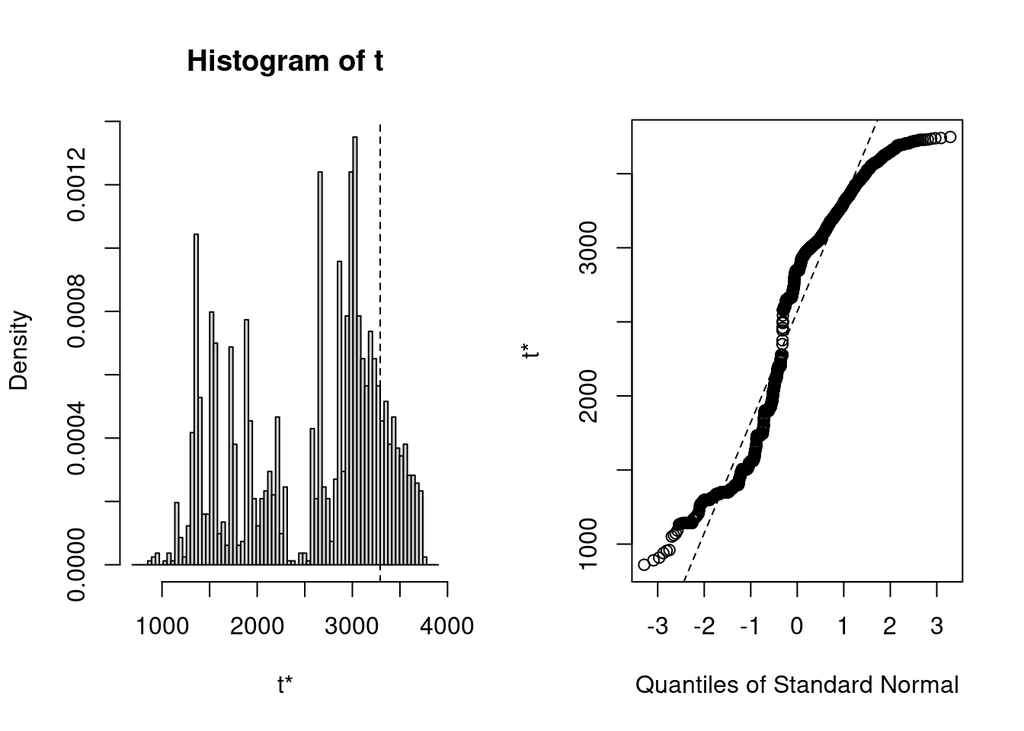

We seem to obtain two Gaussian-ish shaped distributions as the distribution of the optimization values.

## 4.

Estimate the variance of c using the jackknife and compare it with the bootstrap estimate.

```
##   [1] 3080.298 2629.769 3544.595 2921.000 1227.792 3111.594 2856.652 2990.210
##   [9] 3282.935 1505.000 1341.681 2179.999 3071.671 1667.445 3620.839 3458.240
##  [17] 1349.999 1350.000 1277.796 1505.000 1944.936 1904.635 1145.929 3040.812
##  [25] 2147.547 2059.402 1963.501 1400.000 3286.356 2658.974 2638.423 1746.000
##  [33] 1325.163 1306.010 2848.000 3720.023 1583.019 3053.140 3019.888 1715.000
##  [41] 3378.652 2951.618 1920.000 2277.000 3333.380 1746.000 1365.001 2130.801
##  [49] 3144.911 1471.161 2650.000 1948.000 1746.000 1733.001 3333.753 3658.250
##  [57] 3095.331 1338.000 3409.467 1900.000 3406.359 3628.893 3218.517 3325.015
##  [65] 3652.722 3557.158 1400.000 3211.312 1338.000 3272.023 2276.999 3281.985
##  [73] 1746.000 2051.313 2981.006 1915.254 2968.263 2053.429 3015.171 3138.427
##  [81] 2107.148 1546.051 2681.467 2200.000 2773.318 3121.549 1323.306 3433.973
##  [89] 2957.339 2697.218 1142.000 3209.381 2918.669 2951.775 2199.999 1999.996
##  [97] 3560.139 2685.756 1959.940 3190.257 1733.001 2664.001 3233.826 1350.000
## [105] 2600.000 2647.547 3638.916 1339.079 3213.433 3002.315
```

```
## [1] 615380.1
```

(The values we obtain are not accurate, we will wait for feedback to understand what we did wrong.)

## 5.

Summarize the results of your investigation by comparing all of the confidence intervals with respect to their length and the location of c inside them.

# Appendix

```r
knitr::opts_chunk$set(echo = FALSE)
#1.1
data=read.csv("lottery.csv", header = TRUE, sep = ";")
summary(data)
plot(data$Day_of_year, data$Draft_No, xlim = c(0, 366), ylim = c(0, 366), xlab = "Day of year", ylab = "Draft No")
#1.2
model=lm(Draft_No ~ Day_of_year , data=data)
summary(model)
plot(data$Day_of_year, data$Draft_No, xlim = c(0, 366), ylim = c(0, 366), xlab = "Day of year", ylab = "Draft No")
abline(model, col="red")

model2=loess(Draft_No ~ Day_of_year , data=data)
summary(model2)
plot(data$Day_of_year, data$Draft_No, xlim = c(0, 366), ylim = c(0, 366), xlab = "Day of year", ylab = "Draft No")
lines(data$Day_of_year, model2$fitted, col="red")

#1.3
S = sum(abs(model2$fitted-mean(data$Draft_No)))
B=2000
S_boot=rep(NA, B)
for (b in 1:B){
  data_boot=data[sample(1:nrow(data), replace = TRUE),]
  model_boot=loess(Draft_No ~ Day_of_year , data=data_boot)
  S_boot[b]=sum(abs(model_boot$fitted-mean(data_boot$Draft_No)))
}
p_value=mean(S_boot>S)
S
p_value
#1.4
#Permutation test:

test_hyp=function(data){
  model=loess(Draft_No ~ Day_of_year , data=data)
  S=sum(abs(model$fitted-mean(data$Draft_No))) #1: T(X) value of statistic from observed data
  B=2000
  S_boot=rep(NA, B)
  #generate B bootstrap samples without replacement
  for (b in 1:B){
    #2: Create permutations g_1, g_B of group variable {If the number of permutations is too large, sample B randomly without replacement. E.g. generate random permutations and keep only unique ones.}
    data_boot = data
    data_boot$Day_of_year = sample(data$Day_of_year, replace = FALSE) #without replacement
    model_boot=loess(Draft_No ~ Day_of_year , data=data_boot) #fitting the model
    #3: Evaluate test statistic on each permutation
    S_boot[b] = sum(abs(model_boot$fitted-mean(data_boot$Draft_No)))

  }
  p_value=mean(S_boot>=S) #4: Estimate p–value: p^ = #{T(X_gb) >= T(X)}/B
  return(list(S=S, p_value=p_value))
}

test_hyp(data)
#1.5
#(a)
#i k consecutive dates,

#Create a dataset of the same dimensions as the original data.
data2=data

#Choose k, out of the 366, dates and assign them the end numbers of the lottery (i.e., they are not legible for the draw).
#===================
k=300
#===================
#Randomize the first 366-k dates
# data2$Draft_No[366-k:366]=sample(1:(366-k), k, replace = FALSE)
model2=loess(Draft_No ~ Day_of_year , data=data2)
plot(data2$Day_of_year, data2$Draft_No, xlim = c(0, 366), ylim = c(0, 366), xlab = "Day of year", ylab = "Draft No")

#ii. as blocks (randomly scattered) of $\lfloor k/3 \rfloor$  consecutive dates (this is of course for $k ≥ 3$, and if k is not divisible by 3, then some blocks can be of length $ \lfloor k/3 \rfloor +1$).

data3=data

get_lotery_numbers_with_chunks <- function(k){
  #k is the number of dates that are not legible for the draw
  # 3 cases :
  # 1. n_chunks is an integer -> 3 normal chunks
  # 2. n_chunks is not an integer and has a remainder of 1 -> 2 normal chunks and 1 long chunk
  # 3. n_chunks is not an integer and has a remainder of 2 -> 1 normal chunk and 2 long

  #Case 1
  if(k%%3 == 0){
    chunk_size = floor(k/3)
    n_chunks = 3
    for (i in 1:n_chunks){
      #Sample n_chunks_normal chunks of length chunk_size
      #random starting point
      start = sample(1:366, 1, replace = TRUE)
      #sample chunk_size consecutive days
      data3$Draft_No[start:start+chunk_size-1] = sample(1:(366-k), chunk_size, replace = TRUE)
    }

  }

  # chunk_size = floor(k/3)
  # remainder = k%%chunk_size
  # n_chunks_normal = floor(k/chunk_size) - remainder
  # n_chunks_long = remainder
  # for (i in 1:n_chunks_normal){
  # #Sample n_chunks_normal chunks of lenght chunk_size
  # #random starting point
  # start = sample(1:366, 1, replace = TRUE)
  # #sample chunk_size consecutive days
  # data3$Draft_No[start:start+chunk_size-1] = sample(1:(366-k), chunk_size, replace = TRUE)
  # }
  # for (i in 1:n_chunks_long){
  #    #Sample n_chunks_long chunks of lenght chunk_size+1
  #   start = sample(1:366, 1, replace = TRUE)
  #   #sample chunk_size consecutive days
  #   data3$Draft_No[start:start+chunk_size] = sample(1:(366-k), chunk_size+1, replace = TRUE)
  # }
  # data3$Draft_No[n_chunks_normal*chunk_size+n_chunks_long*(chunk_size+1):366] = sample(1:(366-k), 366-k, replace = TRUE)

}



model3=loess(Draft_No ~ Day_of_year , data=data3)
plot(data3$Day_of_year, data3$Draft_No, xlim = c(0, 366), ylim = c(0, 366), xlab = "Day of year", ylab = "Draft No")
#(b)

S=sum(abs(model2$fitted-mean(data2$Draft_No)))
B=2000
S_boot=rep(NA, B)
for (b in 1:B){
  data_boot=data2[sample(1:nrow(data2), replace = TRUE),]
  model_boot=loess(Draft_No ~ Day_of_year , data=data_boot)
  S_boot[b]=sum(abs(model_boot$fitted-mean(data_boot$Draft_No)))
}
p_value=sum(S_boot>S)/B
p_value

#(c)

data <- read.csv("prices1.csv", sep=";")

## 1)

price <- data$Price
sqft <- data$SqFt

plot(sqft, price)
fit1 <- lm(Price ~ SqFt, data)
lines(sqft, fit1$fitted.values, col="darkred", type="l", lwd=1)
## 2)

fit2 <- function(c, data){
  data$new <- rep(0,110)
  for (i in 1:nrow(data)){
    if (data[i,2] > c) data[i,5] <- data[i,2] - c
    else data[i,5] <- 0
  }
  lm2 <- lm(Price ~ SqFt + new, data)
  sum(lm2$residuals^2)
}

RSS_opt <- optim(2000, fit2, data=data, method="L-BFGS-B", lower=0, upper=4500)
RSS_opt$par
RSS_opt$value
library(boot)

c_val <- c()

for (i in 1:2E3){
  if (i%%500==0) cat(i, "\r")
  id <- sample(1:110, 110, replace = TRUE)
  data_boot <- data[id,]
  c_opt <- optim(2000, fit2, data=data_boot, method="L-BFGS-B", lower=0, upper=4500)
  c_val <<- c(c_val, c_opt$par)
}

hist(c_val)

2 * RSS_opt$par - sum(c_val) / 2000      # bootstrap bias-correction
sum((c_val - mean(c_val))^2) / (2000-1)  # variance of c

opt_boot <- function(data, id){
  id <- sample(1:110, 110, replace = TRUE)
  data_boot2 <- data[id,]
  c_opt2 <- optim(2000, fit2, data= data_boot2, method = "L-BFGS-B", lower = 0, upper = 4500)
  c_opt2$par
}

boot_fun <- boot(data = data, opt_boot, R = 2E3)
boot.ci(boot_fun)
plot(boot_fun)

jack_c <-c()

# new function for the jackknife function with 109 rows instead of 110
fit3 <- function(c, data){
  data$new <- rep(0,109)
  for (i in 1:nrow(data)){
    if (data[i,2] > c) data[i,5] <- data[i,2] - c
    else data[i,5] <- 0
  }
  lm2 <- lm(Price ~ SqFt + new, data)
  sum(lm2$residuals^2)
}

for (i in 1:110){
  id <- sample(1:110, 110, replace = TRUE)
  data_boot3 <- data[id,]
  data_jack <- data_boot3[-i,]
  c_opt <- optim(2000, fit3, data=data_jack, method = "L-BFGS-B", lower = 0, upper = 4500)
  jack_c <<- c(jack_c, c_opt$par)
}

jack_c
var(jack_c)
```